# 고급회귀분석 4장

2025-03-17

## 4.1 회귀선의 추정

### (예 4.1)

[표 3.1]에 있는 광고료와 판매액의 표본자료가 얻어진 모집단에 대하여 $\mu_{y \cdot x} = \beta_0 + \beta_1 x$ 가 성립된다고 가정하고 $\beta_1, \beta_0, \mu_{y \cdot x}$의 95% 신뢰구간을 구하시오.

```r
library("glue")
x0 <- c(rep(1, 10)); x1 <- c(4,8,9,8,8,12,6,10,6,9); xbar <- mean(x1)
X <- cbind(x0, x1); y <- c(9, 20, 22, 15, 17, 30, 18, 25, 10, 20)
n <- length(x1)

dataset = data.frame(x1, y)

y_on_x = lm(y ~ x1, data = dataset) ; anova_table = anova(y_on_x)

beta_1_hat = y_on_x$coefficients[2] ; beta_0_hat = y_on_x$coefficients[1]
S_xx = sum((x1 - xbar)^{2}) ; MSE = anova_table$`Mean Sq`[2]
t_0.025_8 = qt(0.025, 8, lower.tail = FALSE)


## beta_1 의 신뢰구간
beta_1_CI = c(beta_1_hat - t_0.025_8 * sqrt(MSE / S_xx),
              beta_1_hat + t_0.025_8 * sqrt(MSE / S_xx))

## beta_0 의 신뢰구간
beta_0_CI = c(beta_0_hat - t_0.025_8 * sqrt(MSE * (1/n + xbar^{2}/ S_xx)),
              beta_0_hat + t_0.025_8 * sqrt(MSE * (1/n + xbar^{2}/ S_xx)))

## x = 4일때 mu_y.x 의 신뢰구간
mu_y.4_CI = c(beta_0_hat + beta_1_hat * 4 - t_0.025_8 * sqrt(MSE * (1/n + (4 - xbar)^{2}/ S_xx)),
              beta_0_hat + beta_1_hat * 4 + t_0.025_8 * sqrt(MSE * (1/n + (4 - xbar)^{2}/ S_xx)))

print(glue("beta_1의 신뢰구간 = ({beta_1_CI[1]},{beta_1_CI[2]})"))
```

```
## beta_1의 신뢰구간 = (1.71431876109785,3.50307254324997)
```

```r
print(glue("beta_0의 신뢰구간 = ({beta_0_CI[1]},{beta_0_CI[2]})"))
```

```
## beta_0의 신뢰구간 = (-9.67725227866451,5.13812184388191)
```

```r
print(glue("x = 4일때 mu_y.x 의 신뢰구간 = ({mu_y.4_CI[1]},{mu_y.4_CI[2]})"))
```

```
## x = 4일때 mu_y.x 의 신뢰구간 = (4.1058890626529,12.2245457199558)
```

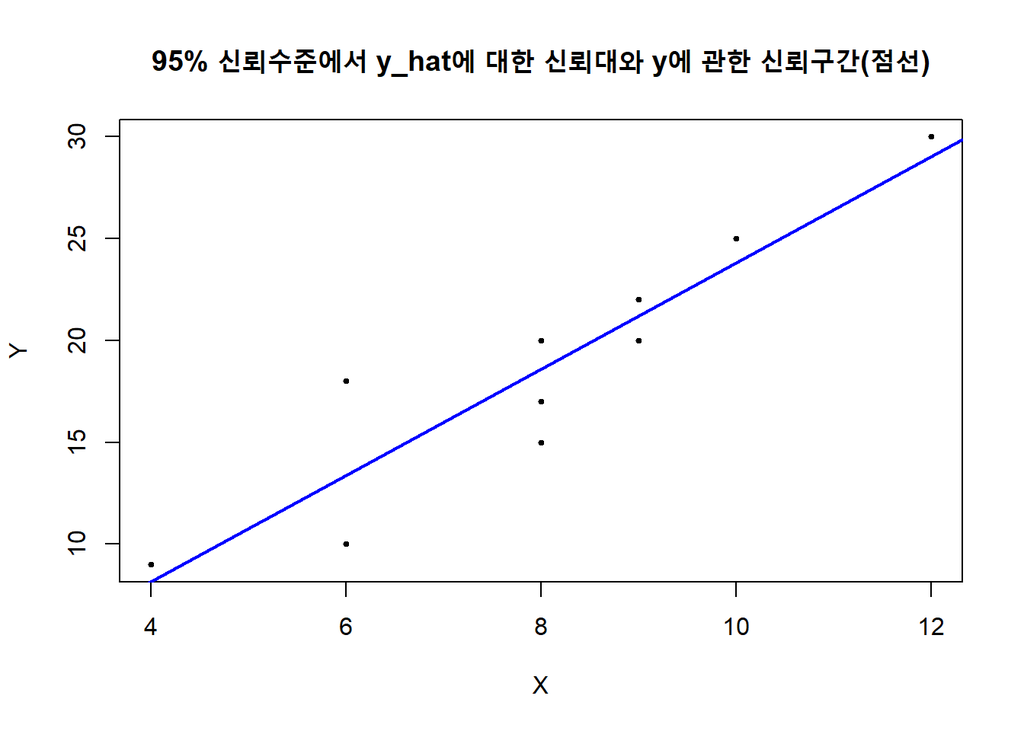

```r
## 95% 신뢰수준에서 mu_y.x에 대한 신뢰대와 y에 대한 신뢰구간
plot(dataset$x1, dataset$y, xlab = "X", ylab = "Y", pch = 19, cex = 0.5, main = "95% 신뢰수준에서 y_hat에 대한 신뢰대와 y에 관한 신뢰구간(점선)")
abline(y_on_x$coefficients, col = "blue", lwd = 2)
```

```r
library(ggplot2)
# 4부터 12까지 x1 값 생성
newx <- data.frame(x1 = seq(4, 12, length.out = 100))

# 예측값과 95% 신뢰구간 계산

## mu_y.x_ci 생성함수
mu_y.x_ci = function(x, alpha, n){
  t_alpha_half = qt(alpha/2, n-2, lower.tail = FALSE)
  mu_y.x_lower = beta_0_hat + beta_1_hat * x - t_alpha_half * sqrt(MSE * (1/n + (x - xbar)^{2}/ S_xx))
  mu_y.x_upper = beta_0_hat + beta_1_hat * x + t_alpha_half * sqrt(MSE * (1/n + (x - xbar)^{2}/ S_xx))

  return(c(mu_y.x_lower, mu_y.x_upper))
}

mu_y.x_CI <- data.frame(lower = rep(0, length(newx$x1)), upper = rep(0, length(newx$x1)))

for(i in 1:length(newx$x1)){
  x = newx$x1[i]
  mu_yx_ci = mu_y.x_ci(x, 0.05, n)
  # cat("mu_yx_ci = (", mu_yx_ci[1], mu_yx_ci[2], ")")
  mu_y.x_CI$lower[i] = mu_yx_ci[1]
  # cat("lower = ", mu_y.x_CI$lower[i] )
  mu_y.x_CI$upper[i] = mu_yx_ci[2]
  # cat("upper = ", mu_y.x_CI$upper[i] )
  # cat("\n")
}

mu_y.x_CI$lower
```

```
##   [1]  4.105889  4.380241  4.654292  4.928027  5.201430  5.474484  5.747173
##   [8]  6.019477  6.291375  6.562848  6.833872  7.104424  7.374478  7.644006
##  [15]  7.912981  8.181370  8.449143  8.716262  8.982693  9.248395  9.513326
##  [22]  9.777443 10.040697 10.303039 10.564415 10.824771 11.084045 11.342177
##  [29] 11.599100 11.854745 12.109040 12.361909 12.613275 12.863056 13.111169
##  [36] 13.357529 13.602048 13.844638 14.085213 14.323684 14.559966 14.793975
##  [43] 15.025633 15.254865 15.481602 15.705783 15.927356 16.146275 16.362509
##  [50] 16.576033 16.786837 16.994920 17.200294 17.402982 17.603017 17.800443
##  [57] 17.995313 18.187689 18.377638 18.565236 18.750561 18.933698 19.114731
##  [64] 19.293747 19.470836 19.646084 19.819578 19.991404 20.161646 20.330384
##  [71] 20.497696 20.663659 20.828343 20.991819 21.154151 21.315403 21.475634
##  [78] 21.634900 21.793253 21.950744 22.107420 22.263325 22.418502 22.572990
##  [85] 22.726825 22.880043 23.032676 23.184754 23.336308 23.487364 23.637947
##  [92] 23.788082 23.937790 24.087094 24.236013 24.384566 24.532770 24.680643
##  [99] 24.828199 24.975454
```

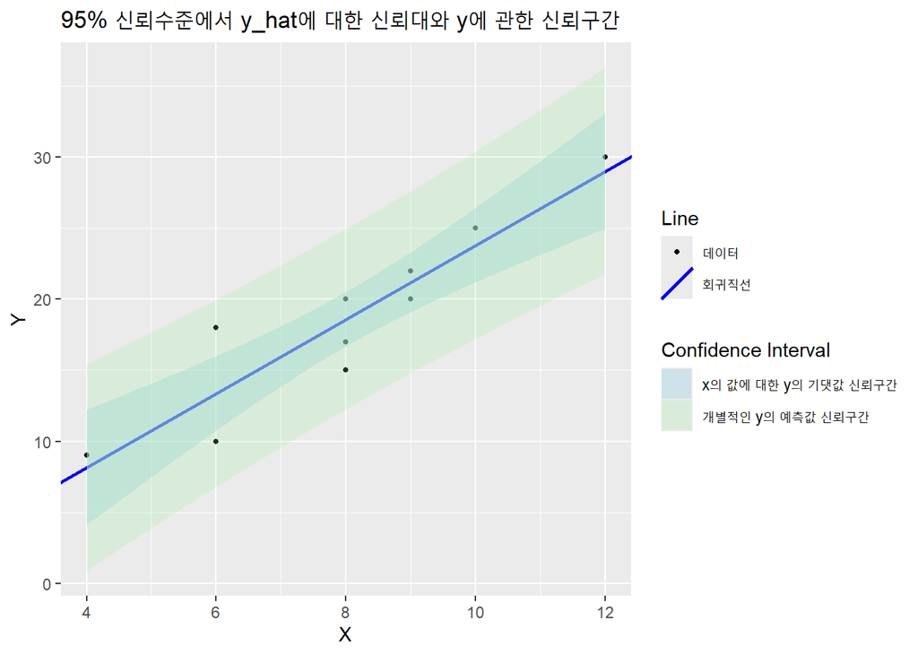

````r
# 개별적인 y값의 예측구간

## y_hat_s_ci 생성함수

y_hat_s_ci = function(x, alpha, n){
  t_alpha_half = qt(alpha/2, n-2, lower.tail = FALSE)
  y_hat_s_ci_lower = beta_0_hat + beta_1_hat * x - t_alpha_half * sqrt(MSE * (1 + 1/n + (x - xbar)^{2}/ S_xx))
  y_hat_s_ci_upper = beta_0_hat + beta_1_hat * x + t_alpha_half * sqrt(MSE * (1 + 1/n + (x - xbar)^{2}/ S_xx))

  return(c(y_hat_s_ci_lower, y_hat_s_ci_upper))
}

y_hat_s_CI <- data.frame(lower = rep(0, length(newx$x1)), upper = rep(0, length(newx$x1)))

for(i in 1:length(newx$x1)){
  x = newx$x1[i]
  y_hat_s_ci_ = y_hat_s_ci(x, 0.05, n)
  # cat("y_hat_s_ci = (", y_hat_s_ci_[1], y_hat_s_ci_[2], ")")
  y_hat_s_CI$lower[i] = y_hat_s_ci_[1]
  # cat("lower = ", y_hat_s_CI$lower[i] )
  y_hat_s_CI$upper[i] = y_hat_s_ci_[2]
  # cat("upper = ", y_hat_s_CI$upper[i] )
  # cat("\n")
}



# newx와 mu_y.x_CI를 하나의 데이터프레임으로 결합 (x1, lower, upper)
mu_y.x_CI_data <- data.frame(
  x1 = newx$x1,
  lower = mu_y.x_CI$lower,
  upper = mu_y.x_CI$upper
)

# newx와 y_hat_s_CI를 하나의 데이터프레임으로 결합 (x1, lower, upper)
y_hat_s_CI_data <- data.frame(
  x1 = newx$x1,
  lower = y_hat_s_CI$lower,
  upper = y_hat_s_CI$upper
)

# # ggplot을 이용한 그래프 그리기
# ggplot(dataset, aes(x = x1, y = y)) +
#   geom_point(shape = 19, size = 1) +  # 데이터 포인트
#   geom_abline(intercept = y_on_x$coefficients[1],
#               slope = y_on_x$coefficients[2],
#               color = "blue", size = 1) +  # 회귀선
#   geom_ribbon(data = mu_y.x_CI_data,
#               aes(x = x1, ymin = lower, ymax = upper),
#               fill = "lightblue", alpha = 0.5, inherit.aes = FALSE) +  # x의 값에 대한 y의 기댓값 신뢰구간 영역
#   geom_ribbon(data = y_hat_s_CI_data,
#               aes(x = x1, ymin = lower, ymax = upper),
#               fill = "lightgreen", alpha = 0.2, inherit.aes = FALSE) +  # 개별적인 y값의 신뢰구간 영역
#   labs(title = "95% 신뢰수준에서 y_hat에 대한 신뢰대와 y에 관한 신뢰구간(점선)",
#        x = "X", y = "Y")
# ```

ggplot() +
  # 데이터 포인트: "Data" 라벨로 지정
  geom_point(data = dataset, aes(x = x1, y = y, color = "데이터"), shape = 19, size = 1) +
  # 회귀선: "Regression line" 라벨로 지정
  geom_abline(aes(intercept = y_on_x$coefficients[1],
                  slope = y_on_x$coefficients[2],
                  color = "회귀직선"), size = 1) +
  # mu_y.x 신뢰구간: "mu_y.x CI" 라벨로 지정
  geom_ribbon(data = mu_y.x_CI_data,
              aes(x = x1, ymin = lower, ymax = upper, fill = "x의 값에 대한 y의 기댓값 신뢰구간"),
              alpha = 0.5, inherit.aes = FALSE) +
  # 개별 y값 신뢰구간: "y_hat CI" 라벨로 지정
  geom_ribbon(data = y_hat_s_CI_data,
              aes(x = x1, ymin = lower, ymax = upper, fill = "개별적인 y의 예측값 신뢰구간"),
              alpha = 0.2, inherit.aes = FALSE) +
  # color legend 설정
  scale_color_manual(name = "Line",
                     values = c("데이터" = "black", "회귀직선" = "blue")) +
  # fill legend 설정
  scale_fill_manual(name = "Confidence Interval",
                    values = c("x의 값에 대한 y의 기댓값 신뢰구간" = "lightblue", "개별적인 y의 예측값 신뢰구간" = "lightgreen")) +
  labs(title = "95% 신뢰수준에서 y_hat에 대한 신뢰대와 y에 관한 신뢰구간",
       x = "X", y = "Y")
````

## 4.4 모형의 타당성

### (예 4.4)

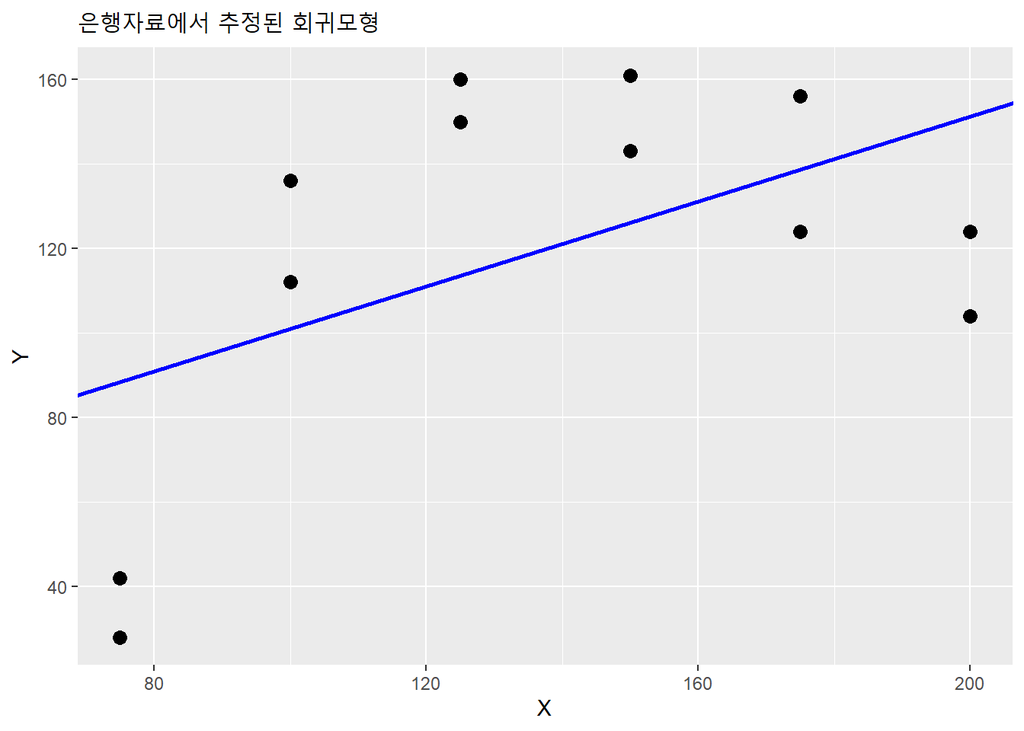

```r
y1 = c(28, 112, 160, 143, 156, 124) ; y2 = c(42, 136, 150, 161, 124, 104)
x = c(75, 100, 125, 150, 175, 200) ; x_ = rep(x, 2) ; y_ = c(y1, y2)

bank_data = data.frame(x_, y_)
y_on_x = lm(y_ ~ x_, data = bank_data)
anova_table = anova(y_on_x)

# ggplot을 이용한 그래프 그리기
ggplot(bank_data, aes(x = x_, y = y_)) +
  geom_point(shape = 19, size = 3) +  # 데이터 포인트
  geom_abline(intercept = y_on_x$coefficients[1],
              slope = y_on_x$coefficients[2],
              color = "blue", size = 1) +  # 회귀선
  labs(title = "은행자료에서 추정된 회귀모형",
       x = "X", y = "Y")
```

```r
## 적합결여검정
n = length(x_) ; k = length(x)
ybar_k = c(rep(0, 6))
for (i in 1:length(x)){
  ybar_k[i] = (y1[i] + y2[i])/2
}
ybar_k
```

```
## [1]  35 124 155 152 140 114
```

```r
SSE = anova_table$`Sum Sq`[2]
SSPE = sum((y1 - ybar_k)^{2}) + sum((y2 - ybar_k)^{2})
SSLF = SSE - SSPE

F_0 = (SSLF/(k-2)) / (SSPE/(n-k)) ; F_0
```

```
## [1] 16.3976
```

```r
F_alpha = qf(0.05,k-2,n-k, lower.tail = FALSE) ; F_alpha
```

```
## [1] 4.533677
```

## 4.6 R 실습

$\textbf{아마존 강 수위 문제}$ 3장 연습문제 10번에 대하여 단순회귀모형을 가정하고 이를 추론해 보기로 한다.

`lm()`함수를 사용하여 반응변수 `High`와 설명변수 `Year`에 대한 단순선형회귀모형을 적합할수 있다. 기본 문법은 `lm(y~x, data)`이다. 이때 `y`는 반응변수, `x`는 설명변수를 가리키며 `data`는 두 변수의 정보가 포함된 자료를 가리킨다.

```r
amazon = read.csv("amazon.csv")
lm.fit = lm(High ~ Year, data = amazon)
lm.fit
```

```
##
## Call:
## lm(formula = High ~ Year, data = amazon)
##
## Coefficients:
## (Intercept)         Year
##   -330.2124       0.1809
```

이 결과로부터 해가 지날수록 아마존 강의 최고 수위는 약 0.1809 미터씩 높아지고 있음을 알 수 있다. 회귀계수에 대한 유의확률값과 표준오차와 결정계수, 그리고 분산분석표의 $F-$값 등은 `summary()`함수를 사용하여 구할 수 있다.

```r
summary(lm.fit)
```

```
##
## Call:
## lm(formula = High ~ Year, data = amazon)
##
## Residuals:
##     Min      1Q  Median      3Q     Max
## -1.3629 -0.5341  0.1479  0.4903  1.1412
##
## Coefficients:
##               Estimate Std. Error t value Pr(>|t|)
## (Intercept) -330.21235   78.03319  -4.232 0.000725 ***
## Year           0.18088    0.03961   4.567 0.000371 ***
## ---
## Signif. codes:  0 '***' 0.001 '**' 0.01 '*' 0.05 '.' 0.1 ' ' 1
##
## Residual standard error: 0.8001 on 15 degrees of freedom
## Multiple R-squared:  0.5816, Adjusted R-squared:  0.5537
## F-statistic: 20.85 on 1 and 15 DF,  p-value: 0.0003708
```

각 회귀계수 추정값에 대한 신뢰구간을 얻기 위해 `confint()`함수를 사용한다.

```r
confint(lm.fit)
```

```
##                     2.5 %       97.5 %
## (Intercept) -496.53615985 -163.8885460
## Year           0.09645429    0.2653104
```

$\mu_{y\cdot x}$에 대한 신뢰구간을 얻기 위해서는 `predict()`함수를 사용할 수 있다. 예를 들어, `Year`가 1970인 경우 $\mu_{y\cdot x}$의 95% 신뢰구간은 다음과 같이 구할 수 있다.

```r
predict(lm.fit, data.frame(Year = 1970), interval = "confidence")
```

```
##        fit      lwr      upr
## 1 26.12588 25.71227 26.53949
```

주어진 $x$에 대하여 $y$의 기대값인 $\mu_{y\cdot x}$ 대신에 하나의 에측값 $y$에 대한 신뢰구간은 `interval = "prediction"`으로 하여 `predict()`함수로부터 구할 수 있다.

```r
predict(lm.fit, data.frame(Year = 1970), interval = "prediction")
```

```
##        fit      lwr      upr
## 1 26.12588 24.37108 27.88069
```

여기서 (Year = 1970)에서 예측한 평균 반응과 하나의 예측값에 대한 추정값은 26.12588으로 동일하지만, 개별적인 예측값에 대한 신뢰구간이 더 넓어지는 것을 알 수 있다.

한편, `residuals`함수를 사용하여 잔차를 구하고, 이 함수를 이용하여 설명변수$x$와 적합값$\hat{y}$에 대한 잔차를 그래프로 나타낼 수 있다. 잔차를 그린 후 0을 중심으로 랜덤하게 나타나는 것인지 확인하기 위해 `scatter.smooth()`함수를 사용하여 그려 보기로 한다. 화면에 2개의 그래프를 보여주기 위해 `par()`함수를 사용하여 화면을 먼저 분할하기로 한다. 예를 들어, `par(mfrow = c(1,2))`를 입력하면 화면이 $1 \times 2$격자로 분할된다.

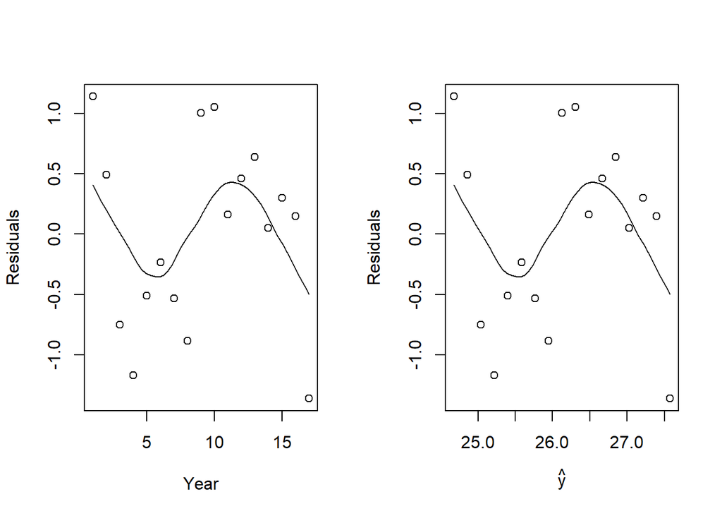

```r
par(mfrow = c(1,2))
scatter.smooth(x = 1:length(amazon$Year), y= residuals(lm.fit),
               xlab = "Year", ylab = "Residuals")
scatter.smooth(x = predict(lm.fit), y= residuals(lm.fit),
               xlab = expression(hat(y)), ylab = "Residuals")
```

설명변수 `Year`에 대한 잔차그림은 시간이 흐름에 따라 잔차의 모양을 보여주는 것으로, 자료의 갯수가 작아 뚜렷하진 않지만 어떤 일정한 주기(cycle)를 가지고 있는 것으로 의심이 된다. 이를 알아보기 위해 오차에 일차자기상관계수의 존재 여부를 검정하는 Durbin-Watson 검정을 시행해보면 다음과 같다. 이를 위해서 간단히 `car`패키지의 `dwt` 함수를 사용해보기로 한다.

```r
# install.packages("car")
library(car)
dwt(lm.fit)
```

```
##  lag Autocorrelation D-W Statistic p-value
##    1        0.311123      1.048677    0.02
##  Alternative hypothesis: rho != 0
```

위 결과로부터 $\hat{\rho} = 0.3$이고, Durbin-Watson 통계량은 $d \approx 1.05$ 임을 알 수 있으며, 유의수준 5%에서 귀무가설 $H_0 : \rho = 0$ 을 기각하고, 오차항 간에 양의 일차자기상관이 존재한다고 할 수 있다.

(예 4.4)에서 살펴본 적합결여검정을 실습해보도록 한다. 먼저, $(x,y)$를 아래와 같이 입력한 후, 단순 선형회귀모형 적합에 대한 분산분석 결과를 다음과 같이 살펴보도록 하자.

```r
x = rep(c(75, 100, 125, 150, 175, 200), 2)
y = c(c(28, 112, 160, 143, 156, 124), c(42, 136, 150, 161, 124, 104))
anova(lm(y ~ x))
```

```
## Analysis of Variance Table
##
## Response: y
##           Df  Sum Sq Mean Sq F value  Pr(>F)
## x          1  5531.4  5531.4  3.5389 0.08935 .
## Residuals 10 15630.6  1563.1
## ---
## Signif. codes:  0 '***' 0.001 '**' 0.01 '*' 0.05 '.' 0.1 ' ' 1
```

이때, $SSE = 15630.6$임을 알 수 있다. 이 잔차의 크기가 모형의 가정이 적절하지 않은 것 때문인지 객관적으로 판단하기 위해서 $x$의 반복이 있는 경우 적합결여검정을 통해 알 수 있다. 위 자료는 같은 $x$에 대한 $y$관측값이 존재한다. 따라서 오차제곱합으로부터 순오차제곱합($SSPE$)을 구해볼 수 있다. 이를 위해 다음과 같이 연속적인 설명변수 $x$를 범주형 변수 (`factor(x)`)로 지정한 후 모형을 적합하면 그 때의 잔차제곱합이 곧 순오차제곱합이 됨을 알 수 있다.

```r
anova(lm(y ~ factor(x)))
```

```
## Analysis of Variance Table
##
## Response: y
##           Df Sum Sq Mean Sq F value  Pr(>F)
## factor(x)  5  19852  3970.4  18.185 0.00145 **
## Residuals  6   1310   218.3
## ---
## Signif. codes:  0 '***' 0.001 '**' 0.01 '*' 0.05 '.' 0.1 ' ' 1
```

```r
SSLF = 15630.6 - 1310
MSLF = SSLF / (6-2)
F0 = MSLF / 218.3 ; F0
```

```
## [1] 16.40014
```

```r
pvalue = 1 - pf(F0, 4, 6) ; pvalue
```

```
## [1] 0.002205842
```

## 연습문제

### 4.3

```r
x_0 = c(rep(1, 14)) ; x_1 = c(3, 1, 5, 8, 1, 4, 2, 6, 9, 3, 5, 7, 2, 6)
y = c(39, 24, 115, 105, 50, 86, 67, 90, 140, 112, 70, 186, 43, 126)
n = length(x_0) ; X = cbind(x_0, x_1)
xbar = mean(x_1) ; xbar
```

```
## [1] 4.428571
```

```r
dataset = data.frame(x_1, y)
lm.fit = lm(y ~ x_1, dataset)

S_xx = sum((x_1 - mean(x_1))^{2})
summary(lm.fit)
```

```
##
## Call:
## lm(formula = y ~ x_1, data = dataset)
##
## Residuals:
##     Min      1Q  Median      3Q     Max
## -33.204 -20.383  -4.748  13.957  61.433
##
## Coefficients:
##             Estimate Std. Error t value Pr(>|t|)
## (Intercept)   29.107     15.969   1.823 0.093341 .
## x_1           13.637      3.149   4.330 0.000978 ***
## ---
## Signif. codes:  0 '***' 0.001 '**' 0.01 '*' 0.05 '.' 0.1 ' ' 1
##
## Residual standard error: 29.11 on 12 degrees of freedom
## Multiple R-squared:  0.6098, Adjusted R-squared:  0.5773
## F-statistic: 18.75 on 1 and 12 DF,  p-value: 0.0009779
```

```r
anova_table = anova(lm.fit)
t_alpha = qt(0.05, n-2, lower.tail = FALSE)
anova_table = anova(lm.fit)
anova_table
```

```
## Analysis of Variance Table
##
## Response: y
##           Df Sum Sq Mean Sq F value    Pr(>F)
## x_1        1  15887 15887.2  18.753 0.0009779 ***
## Residuals 12  10166   847.2
## ---
## Signif. codes:  0 '***' 0.001 '**' 0.01 '*' 0.05 '.' 0.1 ' ' 1
```

```r
MSE = anova_table$`Mean Sq`[2]
## beta_1_hat

a = lm.fit$coefficients[1]
print(glue("({lm.fit$coefficients[2] - t_alpha * sqrt(MSE / S_xx)}, {lm.fit$coefficients[2] + t_alpha * sqrt(MSE / S_xx)})"))
```

```
## (8.02449921266136, 19.2497482789774)
```

```r
print(glue("({lm.fit$coefficients[1] - t_alpha * sqrt(MSE*(1/n + (xbar^{2}/S_xx)))}, {lm.fit$coefficients[1] + t_alpha * sqrt(MSE*(1/n + (xbar^{2}/S_xx) ))})"))
```

```
## (0.645822385018246, 57.5682244377243)
```

```r
print(glue("({lm.fit$coefficients[1] + lm.fit$coefficients[2] * 10  - t_alpha * sqrt(MSE*(1/n + ((10 - xbar)^{2}/S_xx)))},
           {lm.fit$coefficients[1] + lm.fit$coefficients[2] * 10  + t_alpha * sqrt(MSE*(1/n + ((10 - xbar)^{2}/S_xx)))})"))
```

```
## (131.272154315631,
## 199.6843674235)
```

```r
print(glue("({lm.fit$coefficients[1] + lm.fit$coefficients[2] * 10  - t_alpha * sqrt(MSE*(1 + 1/n + ((10 - xbar)^{2}/S_xx)))},
           {lm.fit$coefficients[1] + lm.fit$coefficients[2] * 10  + t_alpha * sqrt(MSE*(1 + 1/n + ((10 - xbar)^{2}/S_xx)))})"))
```

```
## (103.339782497375,
## 227.616739241755)
```

### 4.4

```r
library(glue)

x_0 = c(rep(1, 9)) ; x_1 = c(0.9, 1.3, 2.1, 2.5, 2.4, 1.7, 0.7, 1.2, 1.6)
y = c(2.0, 2.6, 4.3, 5.8, 5.1, 3.2, 1.8, 2.3, 3.0) ; X = cbind(x_0, x_1)
n = length(x_1) ; xbar = sum(x_1) / n ; ybar = sum(y) / n
S_xx = sum((x_1 - xbar)^{2}) ; S_xy = sum((x_1 - xbar)*(y - ybar))
S_yy = sum((y - ybar)^{2})

beta_1_hat = S_xy / S_xx ; beta_0_hat = ybar - beta_1_hat * xbar
MSE = (1/(n-2)) * (S_yy - (S_xy)^{2} / S_xx)

print(glue("beta_1_hat = {beta_1_hat}, beta_0_hat = {beta_0_hat}, MSE = {MSE}"))
```

```
## beta_1_hat = 2.16257668711656, beta_0_hat = -0.115678254942059, MSE = 0.108008082578634
```

#### 4.4 - (1)

```r
beta_1_0 = 1 # 귀무가설

t_0 = (beta_1_hat - beta_1_0)/sqrt(MSE/S_xx) ; t_0
```

```
## [1] 6.387079
```

```r
t_alpha = qt(0.05, n-2, lower.tail = FALSE) ; t_alpha
```

```
## [1] 1.894579
```

#### 4.4 - (2)

```r
y_hat_0 = 3.3 # 귀무가설

y_hat = beta_0_hat + beta_1_hat * 2

t_0 = (y_hat - y_hat_0)/sqrt(MSE*(1/n + (2-xbar)^{2}/S_xx)) ; t_0
```

```
## [1] 6.91423
```

```r
t_alpha = qt(0.05, n-2, lower.tail = FALSE) ; t_alpha
```

```
## [1] 1.894579
```

#### 4.4 - (3)

```r
rho_0 = 0 # 귀무가설

r = S_xy / sqrt(S_xx * S_yy)

t_0 = r/ sqrt((1- r^{2}) / (n-2)) ; t_0
```

```
## [1] 11.88098
```

```r
t_alpha = qt(0.05, n-2, lower.tail = FALSE) ; t_alpha
```

```
## [1] 1.894579
```

#### 4.4 - (4)

```r
rho_0 = 0.4 # 귀무가설

Z = (1/2) * log((1+r)/(1-r)) ; EZ = (1/2) * log((1+rho_0)/(1-rho_0)) ; VarZ = 1/(n-3)

Z_0 = (Z - EZ)/sqrt(VarZ) ; Z_0
```

```
## [1] 4.369044
```

```r
z_alpha = qnorm(0.05, lower.tail = FALSE) ; z_alpha
```

```
## [1] 1.644854
```

### 4.5

#### 4.5 - (1)

```r
y = c(8.5, 8.4, 7.9, 8.1, 7.8, 7.6, 7.3, 7.0, 6.8, 6.7)
x = c(0, 0, 3, 3, 6, 6, 9, 9, 12, 12)
n = 10 ; k = 5

dataset = data.frame(x,y)

lm.fit = lm(y ~ x, data = dataset)
summary(lm.fit)
```

```
##
## Call:
## lm(formula = y ~ x, data = dataset)
##
## Residuals:
##      Min       1Q   Median       3Q      Max
## -0.18500 -0.06000  0.01500  0.05875  0.19000
##
## Coefficients:
##              Estimate Std. Error t value Pr(>|t|)
## (Intercept)  8.460000   0.066097  128.00 1.55e-14 ***
## x           -0.141667   0.008995  -15.75 2.64e-07 ***
## ---
## Signif. codes:  0 '***' 0.001 '**' 0.01 '*' 0.05 '.' 0.1 ' ' 1
##
## Residual standard error: 0.1207 on 8 degrees of freedom
## Multiple R-squared:  0.9688, Adjusted R-squared:  0.9649
## F-statistic: 248.1 on 1 and 8 DF,  p-value: 2.638e-07
```

```r
anova_table = anova(lm.fit)

factor_anova_table = anova(lm(y ~ factor(x)))

SSE = anova_table$`Sum Sq`[2]

SSPE = factor_anova_table$`Sum Sq`[2]

SSLF = SSE - SSPE ; SSLF
```

```
## [1] 0.0215
```

```r
F_0 =  (SSLF / (k-2))/(SSPE / (n-k)) ; F_0
```

```
## [1] 0.377193
```

```r
F_alpha = qf(0.05, k-2, n-k, lower.tail = FALSE) ; F_alpha
```

```
## [1] 5.409451
```

#### 4.5 - (2)

```r
beta_1_hat = lm.fit$coefficients[2]

MSE = SSE / (n-2)
S_xx = sum((x - mean(x))^{2})
t_alpha = qt(0.025, n-2, lower.tail = FALSE)

beta_1_ci_lower = beta_1_hat - t_alpha * sqrt(MSE/S_xx)
beta_1_ci_upper = beta_1_hat + t_alpha * sqrt(MSE/S_xx)

print(glue("beta_1_CI = ({beta_1_ci_lower},{beta_1_ci_upper})"))
```

```
## beta_1_CI = (-0.162408244874576,-0.120925088458758)
```

### 4.6

#### 4.6 - (1)

```r
x = c(seq(1, from = 0 , to = 9))
y = c(120, 135, 162, 181, 215, 234, 277, 313, 374, 422)
n = length(x)

dataset = data.frame(x,y)

lm.fit = lm(y ~ x, data = dataset)
y_hat = predict(lm.fit)

# y_hat_cal = lm.fit$coefficients[1] + lm.fit$coefficients[2] * x ; y_hat_cal

e = y - y_hat ; e
```

```
##          1          2          3          4          5          6          7
##  25.418182   7.369697   1.321212 -12.727273 -11.775758 -25.824242 -15.872727
##          8          9         10
## -12.921212  15.030303  29.981818
```

```r
d_numerator = 0
d_denominator = (e[1])^{2}
for (i in 2:n){
  temp_n = (e[i] - e[i-1])^{2}
  temp_d = (e[i])^{2}
  d_numerator = temp_n + d_numerator
  d_denominator = temp_d + d_denominator
}
d = d_numerator/ d_denominator ; d
```

```
##        10
## 0.5821039
```

#### 4.6 - (2)

```r
lm.fit$coefficients[2]
```

```
##        x
## 33.04848
```

### 4.8

```r
n = 100

x = c(rep(0, n)) ; z = c(rep(0, n)) ; y = c(rep(0, n))


for (i in 1:n){
  x[i] = i/n
  z[i] = sin(i * pi / n)
  y[i] = cos(i * pi / n)
}

epsilon = rnorm(100, mean = 0, sd = 1)
```

#### 4.8 - (1)

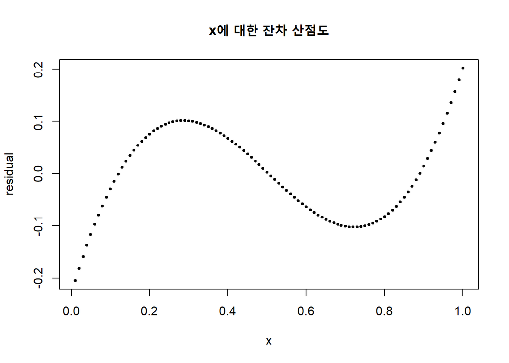

```r
## y = beta_0 + beta_1 x + beta_2 x^{2} + epsilon 가정

x_0 = c(rep(1, n)) ; x_1 = x ; x_2 = x^{2} ; X = cbind(x_0, x_1, x_2)
beta_hat = solve(t(X) %*% X) %*% t(X) %*% y

y_hat = X %*% beta_hat

e = y - y_hat

plot(x, e, xlab = "x", ylab = "residual", main = "x에 대한 잔차 산점도", pch = 19, cex = 0.5)
```

#### 4.8 - (2)

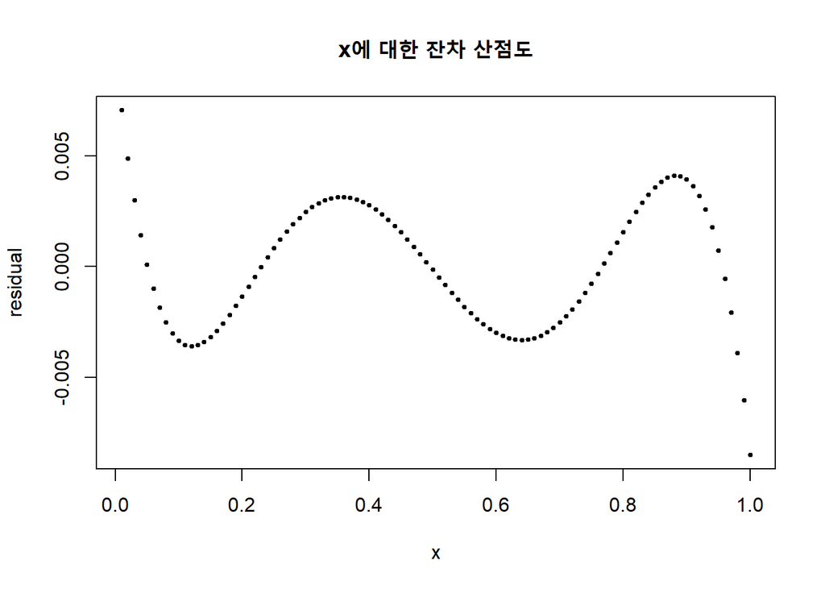

```r
## y = beta_0 + beta_1 x + beta_2 x^{2} + beta_3 x^{3} + epsilon 가정

x_0 = c(rep(1, n)) ; x_1 = x ; x_2 = x^{2} ; x_3 = x^{3} ; X = cbind(x_0, x_1, x_2, x_3)
beta_hat = solve(t(X) %*% X) %*% t(X) %*% y

y_hat = X %*% beta_hat

e = y - y_hat

plot(x, e, xlab = "x", ylab = "residual", main = "x에 대한 잔차 산점도", pch = 19, cex = 0.5)
```

#### 4.8 - (3)

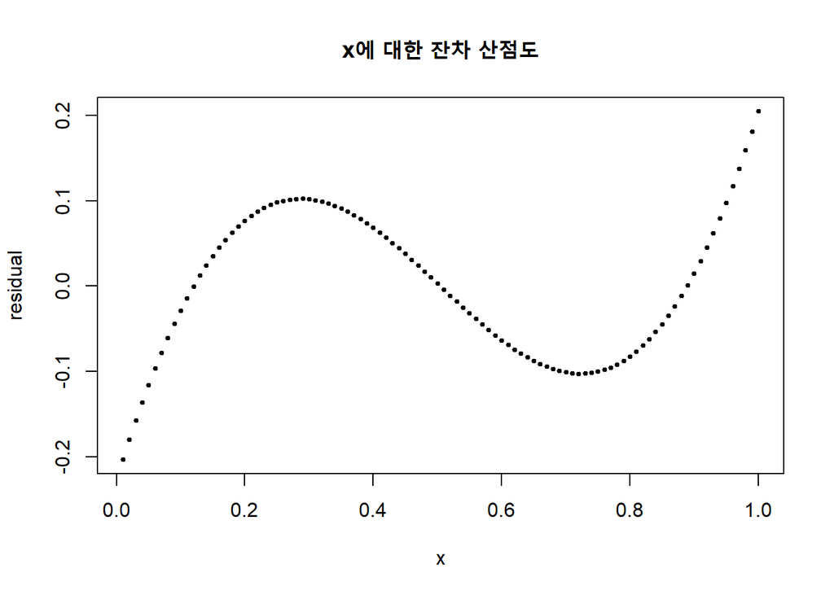

```r
## y = beta_0 + beta_1 x + beta_2 z + epsilon 가정

x_0 = c(rep(1, n)) ; x_1 = x ; x_2 = z ; X = cbind(x_0, x_1, x_2)
beta_hat = solve(t(X) %*% X) %*% t(X) %*% y

y_hat = X %*% beta_hat

e = y - y_hat

plot(x, e, xlab = "x", ylab = "residual", main = "x에 대한 잔차 산점도", pch = 19, cex = 0.5)
```

### 4.11

$\textbf{보스턴 집값 데이터 (데이터 출처 : MASS 패키지)}$ 이 데이터는 Boston 근처 지역의 지역적 특징과 주택 가격의 중앙값 등을 포함하고 있다. 데이터는 MASS 패키지 설치를 통해 Boston 데이터를 사용할 수 있다. 아래와 같이 사용가능하며 자세한 내용을 살펴볼 수 있다.

```r
library(MASS)
head(Boston)
```

```
##      crim zn indus chas   nox    rm  age    dis rad tax ptratio  black lstat
## 1 0.00632 18  2.31    0 0.538 6.575 65.2 4.0900   1 296    15.3 396.90  4.98
## 2 0.02731  0  7.07    0 0.469 6.421 78.9 4.9671   2 242    17.8 396.90  9.14
## 3 0.02729  0  7.07    0 0.469 7.185 61.1 4.9671   2 242    17.8 392.83  4.03
## 4 0.03237  0  2.18    0 0.458 6.998 45.8 6.0622   3 222    18.7 394.63  2.94
## 5 0.06905  0  2.18    0 0.458 7.147 54.2 6.0622   3 222    18.7 396.90  5.33
## 6 0.02985  0  2.18    0 0.458 6.430 58.7 6.0622   3 222    18.7 394.12  5.21
##   medv
## 1 24.0
## 2 21.6
## 3 34.7
## 4 33.4
## 5 36.2
## 6 28.7
```

```r
# ?Boston
```

1인당 범죄율 `crim`을 설명변수 `x`로 하고, 주택가격의 중앙값 `medv`을 반응변수 `y`로 할때 다음에 대하여 답하시오.

#### 4.11 - (1)

선형회귀모형 $y= \beta_0 + \beta_1 x + \epsilon$을 적합하시오.

```r
dataset = Boston

lm.fit = lm(medv ~ crim, data = dataset)
summary(lm.fit)
```

```
##
## Call:
## lm(formula = medv ~ crim, data = dataset)
##
## Residuals:
##     Min      1Q  Median      3Q     Max
## -16.957  -5.449  -2.007   2.512  29.800
##
## Coefficients:
##             Estimate Std. Error t value Pr(>|t|)
## (Intercept) 24.03311    0.40914   58.74   <2e-16 ***
## crim        -0.41519    0.04389   -9.46   <2e-16 ***
## ---
## Signif. codes:  0 '***' 0.001 '**' 0.01 '*' 0.05 '.' 0.1 ' ' 1
##
## Residual standard error: 8.484 on 504 degrees of freedom
## Multiple R-squared:  0.1508, Adjusted R-squared:  0.1491
## F-statistic: 89.49 on 1 and 504 DF,  p-value: < 2.2e-16
```

#### 4.11 -(2)

잔차의 산점도를 그려보고 모형의 타당성과 공분산성에 대하여 설명하시오.

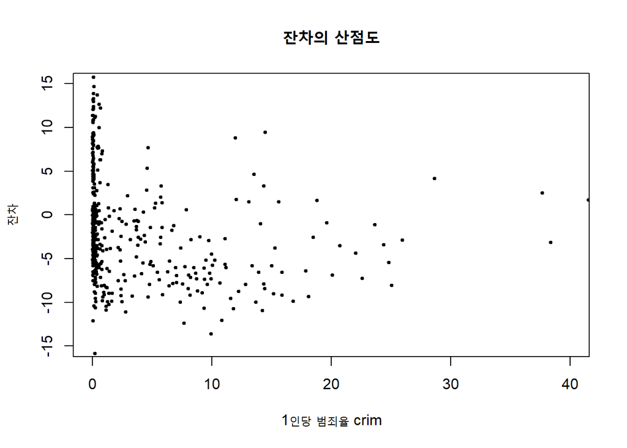

```r
y_hat = predict(lm.fit) ; y = dataset$medv ; x = dataset$crim ; n = length(x)

e = y - y_hat

plot(x, e, xlab = "1인당 범죄율 crim", ylab = "잔차", main = "잔차의 산점도", pch = 19, cex = 0.5,
     ylim = c(-15, 15), xlim = c(0,40))
```

산점도를 그려본 결과 잔차들이 0을 주변으로 대체로 산포하나 $x (crim) = 0$근처에서 잔차가 밀집되어있음을 확인할 수 있다. 명확한 확인을 위해 $x=0$ 근처를 좀 더 자세히 들여다보면

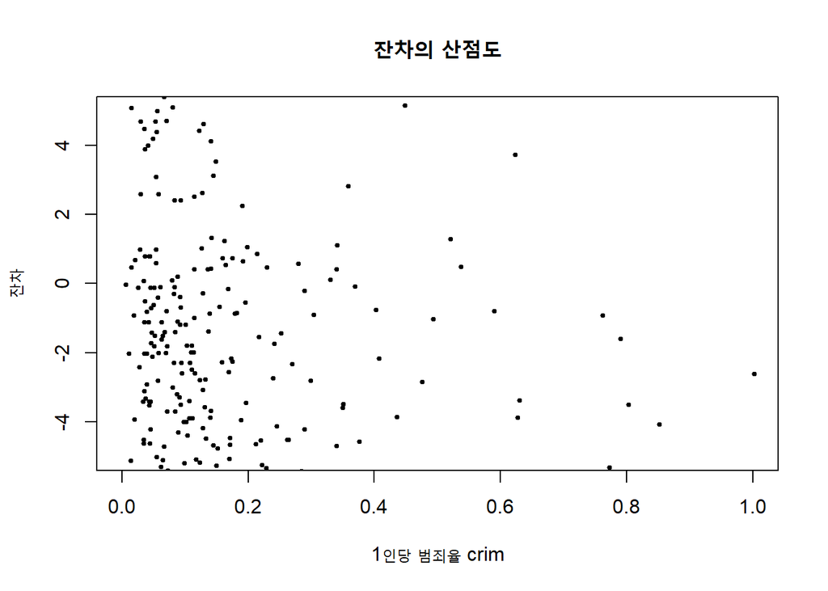

```r
plot(x, e, xlab = "1인당 범죄율 crim", ylab = "잔차", main = "잔차의 산점도", pch = 19, cex = 0.5,
     ylim = c(-5, 5), xlim = c(0,1))
```

다음은 $\hat{y}$와 잔차간의 산점도를 같이 그려놓고 비교해본 결과이다.

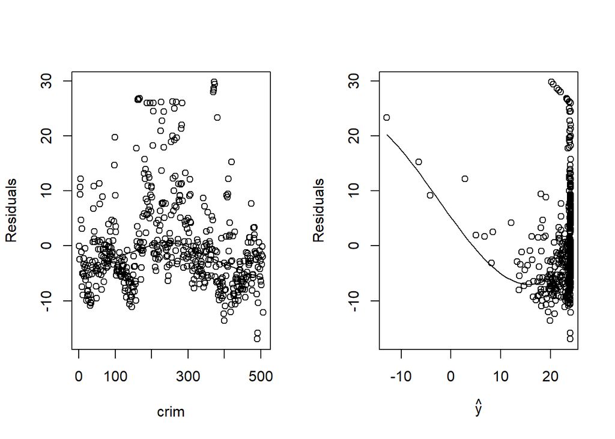

```r
par(mfrow = c(1,2))
scatter.smooth(x = 1:length(dataset$crim), y= residuals(lm.fit),
               xlab = "crim", ylab = "Residuals")
scatter.smooth(x = predict(lm.fit), y= residuals(lm.fit),
               xlab = expression(hat(y)), ylab = "Residuals")
```

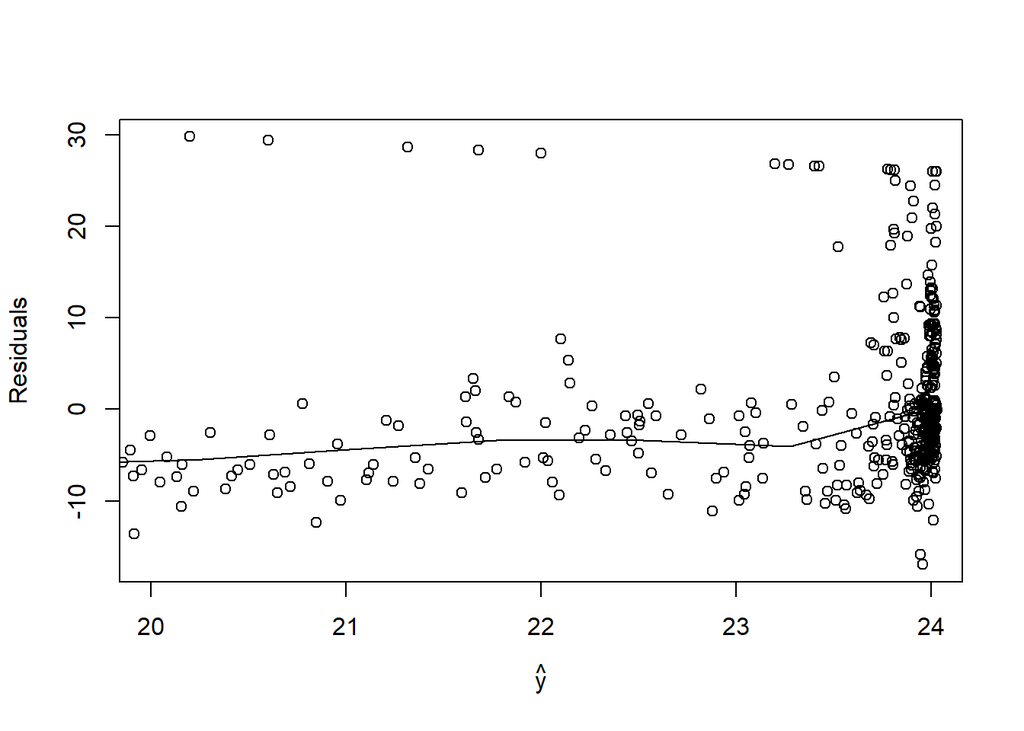

```r
scatter.smooth(x = predict(lm.fit), y= residuals(lm.fit),
               xlab = expression(hat(y)), ylab = "Residuals", xlim = c(20,24))
```

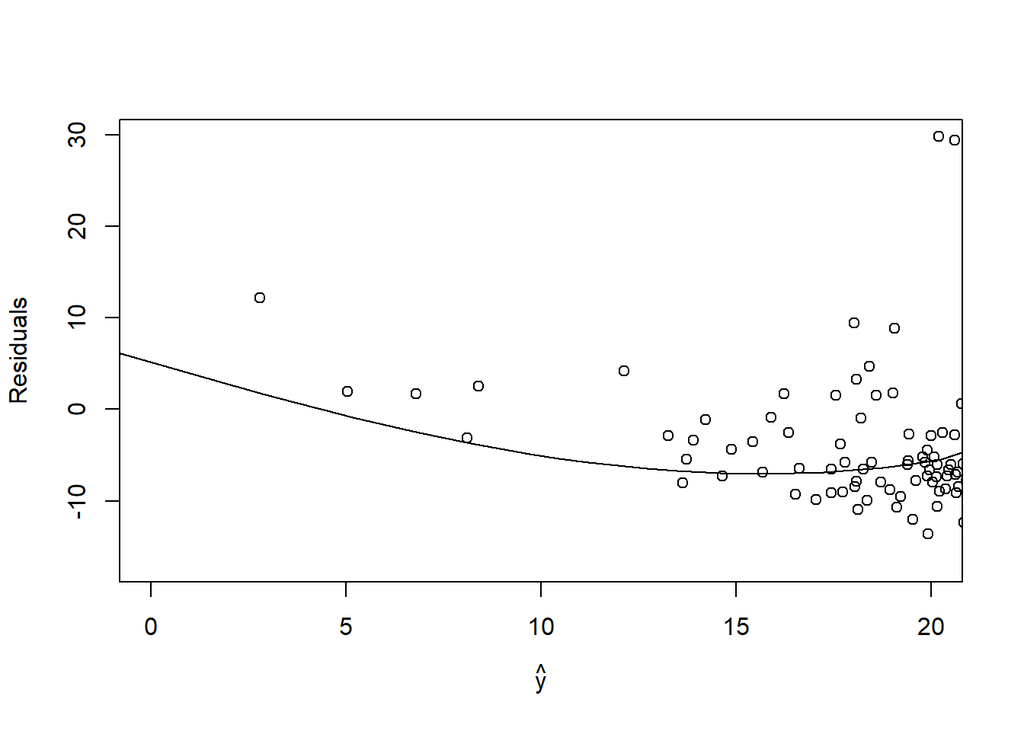

```r
scatter.smooth(x = predict(lm.fit), y= residuals(lm.fit),
               xlab = expression(hat(y)), ylab = "Residuals", xlim = c(0,20))
```

#### 4.11 - (3)

유의수준 $\alpha = 0.1$에서 $H_0 : \beta_1 = 0.3 ~~\text{vs}~~H_1 : \beta_1 \neq 0.3$을 검정하시오.

```r
anova_table = anova(lm.fit)
beta_1_hat = lm.fit$coefficients[2] ; beta_1_0 = 0.3
S_xx = sum((x - mean(x))^{2}) ; MSE = anova_table$`Mean Sq`[2]
t_0 = (beta_1_hat - beta_1_0) / sqrt(MSE / S_xx)
t_alpha = qt(0.05, n-2, lower.tail = FALSE)

print(glue("t_0 = {t_0}, t_alpha = {t_alpha}"))
```

```
## t_0 = -16.2949207615693, t_alpha = 1.64788257711788
```

즉 검정통계량 $|t_0|$ > $t_{\alpha/2}(n-2)$ 이므로 귀무가설을 기각하고 대립가설을 채택한다. 유의수준 0.1에서 $\beta_1 \neq 0.3$ 이라고 할 수 있다.

#### 4.11 - (4)

Durbin-Watson $d$ 통계량을 사용하여 $H_0 : \rho = 0 ~~\text{vs}~~H_1 : \rho > 0$을 유의수준 $\alpha = 0.05$에서 검정하시오.

```r
library(car)
dwt(lm.fit)
```

```
##  lag Autocorrelation D-W Statistic p-value
##    1       0.6412685     0.7134181       0
##  Alternative hypothesis: rho != 0
```